# Cyclistic

Amira

November 28, 2021

## leveraging Cyclistic bike-share Success

This is the case study, for Google data analytics Certificate, Cyclistic, a bike-share company in Chicago features more than 5,800 bicycles and 600 docking stations offering reclining bikes, hand tricycles, and cargo bikes, making bike-share more inclusive to people with disabilities and riders who can’t use a standard two-wheeled bike.

- 8% of riders use the assistive options
- 30% use them to commute to work each day
- Lily Moreno: The director of marketing and your manager, believes the company’s future success depends on maximizing the number of annual memberships
- Customers who purchase single-ride or full-day passes are referred to as **casual** riders
- Customers who purchase annual memberships are Cyclistic **members**
- pricing plans: single-ride passes, full-day passes, and annual memberships.

Moreno believes there is a very good chance to convert casual riders into members. Three questions will guide the future marketing program:

1.How do annual members and casual riders use Cyclistic bikes differently?

2.Why would casual riders buy Cyclistic annual memberships?

3.How can Cyclistic use digital media to influence casual riders to become members?

## Loading Dataset and exploring its Variables

```r
df<- read.csv("D:/Downloads/Google DA Course/Case Study/Case-Study-1/Data/Cyclist_2020.csv")
head(df)
```

```
##            ride_id rideable_type          started_at            ended_at
## 1 EACB19130B0CDA4A   docked_bike 2020-01-21 20:06:59 2020-01-21 20:14:30
## 2 8FED874C809DC021   docked_bike 2020-01-30 14:22:39 2020-01-30 14:26:22
## 3 789F3C21E472CA96   docked_bike 2020-01-09 19:29:26 2020-01-09 19:32:17
## 4 C9A388DAC6ABF313   docked_bike 2020-01-06 16:17:07 2020-01-06 16:25:56
## 5 943BC3CBECCFD662   docked_bike 2020-01-30 08:37:16 2020-01-30 08:42:48
## 6 6D9C8A6938165C11   docked_bike 2020-01-10 12:33:05 2020-01-10 12:37:54
##         start_station_name start_station_id               end_station_name
## 1 Western Ave & Leland Ave              239          Clark St & Leland Ave
## 2  Clark St & Montrose Ave              234 Southport Ave & Irving Park Rd
## 3   Broadway & Belmont Ave              296       Wilton Ave & Belmont Ave
## 4   Clark St & Randolph St               51       Fairbanks Ct & Grand Ave
## 5     Clinton St & Lake St               66          Wells St & Hubbard St
## 6    Wells St & Hubbard St              212    Desplaines St & Randolph St
##   end_station_id start_lat start_lng end_lat  end_lng member_casual
## 1          326.0   41.9665  -87.6884 41.9671 -87.6674        member
## 2          318.0   41.9616  -87.6660 41.9542 -87.6644        member
## 3          117.0   41.9401  -87.6455 41.9402 -87.6530        member
## 4           24.0   41.8846  -87.6319 41.8918 -87.6206        member
## 5          212.0   41.8856  -87.6418 41.8899 -87.6343        member
## 6           96.0   41.8899  -87.6343 41.8846 -87.6446        member
```

- SO this data is for the Year 2020 (12 month starting from January 2020 to December 2020)

```r
str(df)
```

```
## 'data.frame':    3541683 obs. of  13 variables:
##  $ ride_id           : Factor w/ 3541474 levels "000001004784CD35",..: 3248358 1990504 1668016 2790169 2049892 1515730 690239 2250149 1302586 356813 ...
##  $ rideable_type     : Factor w/ 3 levels "classic_bike",..: 2 2 2 2 2 2 2 2 2 2 ...
##  $ started_at        : Factor w/ 3088593 levels "2020-01-01 00:04:44",..: 89046 126625 43584 23366 125179 46802 46949 44870 132970 131198 ...
##  $ ended_at          : Factor w/ 3077059 levels "2020-01-01 00:10:54",..: 89084 126692 43537 23315 125199 46751 46895 44838 133007 131293 ...
##  $ start_station_name: Factor w/ 695 levels "","2112 W Peterson Ave",..: 669 145 58 148 158 647 216 216 647 141 ...
##  $ start_station_id  : Factor w/ 1843 levels "","100","100.0",..: 552 544 674 1120 1405 498 1536 1536 498 842 ...
##  $ end_station_name  : Factor w/ 695 levels "","2112 W Peterson Ave",..: 142 564 676 253 647 216 647 647 216 477 ...
##  $ end_station_id    : Factor w/ 1311 levels "","100.0","101.0",..: 503 494 18 409 381 1010 381 381 1010 2 ...
##  $ start_lat         : num  42 42 41.9 41.9 41.9 ...
##  $ start_lng         : num  -87.7 -87.7 -87.6 -87.6 -87.6 ...
##  $ end_lat           : num  42 42 41.9 41.9 41.9 ...
##  $ end_lng           : num  -87.7 -87.7 -87.7 -87.6 -87.6 ...
##  $ member_casual     : Factor w/ 2 levels "casual","member": 2 2 2 2 2 2 2 2 2 2 ...
```

```r
summary(df)
```

```
##              ride_id              rideable_type
##  021A73F8C18B932D:      2   classic_bike :  70616
##  0334987B57662109:      2   docked_bike  :2966322
##  038CAB4A84D9A56B:      2   electric_bike: 504745
##  0425DA22910BD202:      2
##  05498BABECEB55B0:      2
##  06AD9EC9352D7A00:      2
##  (Other)         :3541671
##                started_at                     ended_at
##  2020-07-12 13:16:59:     12   2020-07-15 11:44:46:     18
##  2020-09-07 15:19:26:     12   2020-09-10 11:14:33:     17
##  2020-08-06 18:23:49:     11   2020-07-11 15:35:03:     13
##  2020-08-18 17:46:44:     11   2020-10-14 07:23:00:     13
##  2020-08-21 18:03:36:     11   2020-09-10 10:39:59:     12
##  2020-08-22 16:42:27:     11   2020-09-16 18:15:01:     12
##  (Other)            :3541615   (Other)            :3541598
##                   start_station_name  start_station_id
##                            :  94656          :  95282
##  Streeter Dr & Grand Ave   :  35366   35.0   :  27625
##  Clark St & Elm St         :  31970   177.0  :  25197
##  Theater on the Lake       :  29609   76.0   :  23465
##  Lake Shore Dr & Monroe St :  29233   176.0  :  21586
##  Lake Shore Dr & North Blvd:  26656   268.0  :  20499
##  (Other)                   :3294193   (Other):3328029
##                    end_station_name   end_station_id      start_lat
##                            : 110881          : 111342   Min.   :41.64
##  Streeter Dr & Grand Ave   :  37766   35.0   :  37322   1st Qu.:41.88
##  Clark St & Elm St         :  32024   176.0  :  30669   Median :41.90
##  Theater on the Lake       :  31058   177.0  :  30615   Mean   :41.90
##  Lake Shore Dr & Monroe St :  28427   76.0   :  27774   3rd Qu.:41.93
##  Lake Shore Dr & North Blvd:  27139   268.0  :  26741   Max.   :42.08
##  (Other)                   :3274388   (Other):3277220
##    start_lng         end_lat         end_lng       member_casual
##  Min.   :-87.87   Min.   :41.54   Min.   :-87.89   casual:1366575
##  1st Qu.:-87.66   1st Qu.:41.88   1st Qu.:-87.66   member:2175108
##  Median :-87.64   Median :41.90   Median :-87.64
##  Mean   :-87.64   Mean   :41.90   Mean   :-87.64
##  3rd Qu.:-87.63   3rd Qu.:41.93   3rd Qu.:-87.63
##  Max.   :-87.52   Max.   :42.16   Max.   :-87.44
##                   NA's   :4255    NA's   :4255
```

```r
skim_without_charts(df)
```

Data summary

| Name | df |
| --- | --- |
| Number of rows | 3541683 |
| Number of columns | 13 |
| _______________________ |  |
| Column type frequency: |  |
| factor | 9 |
| numeric | 4 |
| ________________________ |  |
| Group variables | None |

**Variable type: factor**

| skim_variable | n_missing | complete_rate | ordered | n_unique | top_counts |
| --- | --- | --- | --- | --- | --- |
| ride_id | 0 | 1 | FALSE | 3541474 | 021: 2, 033: 2, 038: 2, 042: 2 |
| rideable_type | 0 | 1 | FALSE | 3 | doc: 2966322, ele: 504745, cla: 70616 |
| started_at | 0 | 1 | FALSE | 3088593 | 202: 12, 202: 12, 202: 11, 202: 11 |
| ended_at | 0 | 1 | FALSE | 3077059 | 202: 18, 202: 17, 202: 13, 202: 13 |
| start_station_name | 0 | 1 | FALSE | 695 | emp: 94656, Str: 35366, Cla: 31970, The: 29609 |
| start_station_id | 0 | 1 | FALSE | 1843 | emp: 95282, 35.: 27625, 177: 25197, 76.: 23465 |
| end_station_name | 0 | 1 | FALSE | 695 | emp: 110881, Str: 37766, Cla: 32024, The: 31058 |
| end_station_id | 0 | 1 | FALSE | 1311 | emp: 111342, 35.: 37322, 176: 30669, 177: 30615 |
| member_casual | 0 | 1 | FALSE | 2 | mem: 2175108, cas: 1366575 |

**Variable type: numeric**

| skim_variable | n_missing | complete_rate | mean | sd | p0 | p25 | p50 | p75 | p100 |
| --- | --- | --- | --- | --- | --- | --- | --- | --- | --- |
| start_lat | 0 | 1 | 41.90 | 0.04 | 41.64 | 41.88 | 41.90 | 41.93 | 42.08 |
| start_lng | 0 | 1 | -87.64 | 0.03 | -87.87 | -87.66 | -87.64 | -87.63 | -87.52 |
| end_lat | 4255 | 1 | 41.90 | 0.04 | 41.54 | 41.88 | 41.90 | 41.93 | 42.16 |
| end_lng | 4255 | 1 | -87.65 | 0.03 | -87.89 | -87.66 | -87.64 | -87.63 | -87.44 |

## Making a copy of the data & Cleaning it:

- Make Acopy of the original Data frame
- Change the type of started_at, ended_at Columns to datetime
- Filter/Select Data to exclude start_lat, start_lng, end_lat & end_lng (containing missing values)
- Calculate “Ride Length” Column
- Calculate “day_of_week”Column
- There are some rides where tripduration shows up as negative, including several hundred rides where Cyclistic took bikes out of circulation for Quality Control reasons, We will want to delete these rides.

```r
trips <- df%>%
  select(-c('start_lat','start_lng', 'end_lat', 'end_lng'))
```

```r
head(trips)
```

```
##            ride_id rideable_type          started_at            ended_at
## 1 EACB19130B0CDA4A   docked_bike 2020-01-21 20:06:59 2020-01-21 20:14:30
## 2 8FED874C809DC021   docked_bike 2020-01-30 14:22:39 2020-01-30 14:26:22
## 3 789F3C21E472CA96   docked_bike 2020-01-09 19:29:26 2020-01-09 19:32:17
## 4 C9A388DAC6ABF313   docked_bike 2020-01-06 16:17:07 2020-01-06 16:25:56
## 5 943BC3CBECCFD662   docked_bike 2020-01-30 08:37:16 2020-01-30 08:42:48
## 6 6D9C8A6938165C11   docked_bike 2020-01-10 12:33:05 2020-01-10 12:37:54
##         start_station_name start_station_id               end_station_name
## 1 Western Ave & Leland Ave              239          Clark St & Leland Ave
## 2  Clark St & Montrose Ave              234 Southport Ave & Irving Park Rd
## 3   Broadway & Belmont Ave              296       Wilton Ave & Belmont Ave
## 4   Clark St & Randolph St               51       Fairbanks Ct & Grand Ave
## 5     Clinton St & Lake St               66          Wells St & Hubbard St
## 6    Wells St & Hubbard St              212    Desplaines St & Randolph St
##   end_station_id member_casual
## 1          326.0        member
## 2          318.0        member
## 3          117.0        member
## 4           24.0        member
## 5          212.0        member
## 6           96.0        member
```

### Add columns that list the date, month, day, and year of each ride

```r
trips$date <- as.Date(trips$started_at) #The default format is yyyy-mm-dd
trips$month <- format(as.Date(trips$date), "%m")
trips$day <- format(as.Date(trips$date), "%d")
trips$year <- format(as.Date(trips$date), "%Y")
trips$day_of_week <- format(as.Date(trips$date), "%A")
```

Test

```r
head(trips)
```

```
##            ride_id rideable_type          started_at            ended_at
## 1 EACB19130B0CDA4A   docked_bike 2020-01-21 20:06:59 2020-01-21 20:14:30
## 2 8FED874C809DC021   docked_bike 2020-01-30 14:22:39 2020-01-30 14:26:22
## 3 789F3C21E472CA96   docked_bike 2020-01-09 19:29:26 2020-01-09 19:32:17
## 4 C9A388DAC6ABF313   docked_bike 2020-01-06 16:17:07 2020-01-06 16:25:56
## 5 943BC3CBECCFD662   docked_bike 2020-01-30 08:37:16 2020-01-30 08:42:48
## 6 6D9C8A6938165C11   docked_bike 2020-01-10 12:33:05 2020-01-10 12:37:54
##         start_station_name start_station_id               end_station_name
## 1 Western Ave & Leland Ave              239          Clark St & Leland Ave
## 2  Clark St & Montrose Ave              234 Southport Ave & Irving Park Rd
## 3   Broadway & Belmont Ave              296       Wilton Ave & Belmont Ave
## 4   Clark St & Randolph St               51       Fairbanks Ct & Grand Ave
## 5     Clinton St & Lake St               66          Wells St & Hubbard St
## 6    Wells St & Hubbard St              212    Desplaines St & Randolph St
##   end_station_id member_casual       date month day year day_of_week
## 1          326.0        member 2020-01-21    01  21 2020     Tuesday
## 2          318.0        member 2020-01-30    01  30 2020    Thursday
## 3          117.0        member 2020-01-09    01  09 2020    Thursday
## 4           24.0        member 2020-01-06    01  06 2020      Monday
## 5          212.0        member 2020-01-30    01  30 2020    Thursday
## 6           96.0        member 2020-01-10    01  10 2020      Friday
```

## change started_at and ended_at columns into datetime

```r
trips$started_at <- as_datetime(trips$started_at)
trips$ended_at <- as_datetime(trips$ended_at)
trips$ride_length <- difftime(trips$ended_at , trips$started_at)
```

## Test

```r
head(trips)
```

```
##            ride_id rideable_type          started_at            ended_at
## 1 EACB19130B0CDA4A   docked_bike 2020-01-21 20:06:59 2020-01-21 20:14:30
## 2 8FED874C809DC021   docked_bike 2020-01-30 14:22:39 2020-01-30 14:26:22
## 3 789F3C21E472CA96   docked_bike 2020-01-09 19:29:26 2020-01-09 19:32:17
## 4 C9A388DAC6ABF313   docked_bike 2020-01-06 16:17:07 2020-01-06 16:25:56
## 5 943BC3CBECCFD662   docked_bike 2020-01-30 08:37:16 2020-01-30 08:42:48
## 6 6D9C8A6938165C11   docked_bike 2020-01-10 12:33:05 2020-01-10 12:37:54
##         start_station_name start_station_id               end_station_name
## 1 Western Ave & Leland Ave              239          Clark St & Leland Ave
## 2  Clark St & Montrose Ave              234 Southport Ave & Irving Park Rd
## 3   Broadway & Belmont Ave              296       Wilton Ave & Belmont Ave
## 4   Clark St & Randolph St               51       Fairbanks Ct & Grand Ave
## 5     Clinton St & Lake St               66          Wells St & Hubbard St
## 6    Wells St & Hubbard St              212    Desplaines St & Randolph St
##   end_station_id member_casual       date month day year day_of_week
## 1          326.0        member 2020-01-21    01  21 2020     Tuesday
## 2          318.0        member 2020-01-30    01  30 2020    Thursday
## 3          117.0        member 2020-01-09    01  09 2020    Thursday
## 4           24.0        member 2020-01-06    01  06 2020      Monday
## 5          212.0        member 2020-01-30    01  30 2020    Thursday
## 6           96.0        member 2020-01-10    01  10 2020      Friday
##   ride_length
## 1    451 secs
## 2    223 secs
## 3    171 secs
## 4    529 secs
## 5    332 secs
## 6    289 secs
```

```r
str(trips)
```

```
## 'data.frame':    3541683 obs. of  15 variables:
##  $ ride_id           : Factor w/ 3541474 levels "000001004784CD35",..: 3248358 1990504 1668016 2790169 2049892 1515730 690239 2250149 1302586 356813 ...
##  $ rideable_type     : Factor w/ 3 levels "classic_bike",..: 2 2 2 2 2 2 2 2 2 2 ...
##  $ started_at        : POSIXct, format: "2020-01-21 20:06:59" "2020-01-30 14:22:39" ...
##  $ ended_at          : POSIXct, format: "2020-01-21 20:14:30" "2020-01-30 14:26:22" ...
##  $ start_station_name: Factor w/ 695 levels "","2112 W Peterson Ave",..: 669 145 58 148 158 647 216 216 647 141 ...
##  $ start_station_id  : Factor w/ 1843 levels "","100","100.0",..: 552 544 674 1120 1405 498 1536 1536 498 842 ...
##  $ end_station_name  : Factor w/ 695 levels "","2112 W Peterson Ave",..: 142 564 676 253 647 216 647 647 216 477 ...
##  $ end_station_id    : Factor w/ 1311 levels "","100.0","101.0",..: 503 494 18 409 381 1010 381 381 1010 2 ...
##  $ member_casual     : Factor w/ 2 levels "casual","member": 2 2 2 2 2 2 2 2 2 2 ...
##  $ date              : Date, format: "2020-01-21" "2020-01-30" ...
##  $ month             : chr  "01" "01" "01" "01" ...
##  $ day               : chr  "21" "30" "09" "06" ...
##  $ year              : chr  "2020" "2020" "2020" "2020" ...
##  $ day_of_week       : chr  "Tuesday" "Thursday" "Thursday" "Monday" ...
##  $ ride_length       : 'difftime' num  451 223 171 529 ...
##   ..- attr(*, "units")= chr "secs"
```

```r
trips$ride_length <- as.numeric(trips$ride_length)
is.numeric(trips$ride_length)
```

```
## [1] TRUE
```

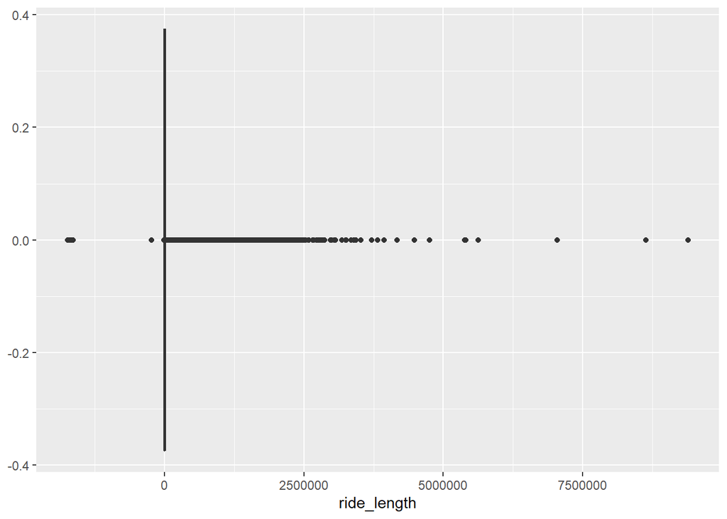

```r
ggplot(trips) +
  geom_boxplot(mapping = aes(x = ride_length))
```

### trim df to exclude -ve rides, and trips starting at HQ QR ### create a new version of the data frame with the filtered values

```r
trips_cleaned <- trips[!(trips$start_station_name == "HQ QR"|trips$ride_length <= 0),]
```

```r
dim(trips_cleaned)
```

```
## [1] 3527000      15
```

```r
summary(trips_cleaned$ride_length)
```

```
##    Min. 1st Qu.  Median    Mean 3rd Qu.    Max.
##       1     462     848    1680    1561 9387024
```

```r
trips_cleaned$ride_length_minutes <- trips_cleaned$ride_length / 60
```

```r
summary(trips_cleaned$ride_length_minutes)
```

```
##      Min.   1st Qu.    Median      Mean   3rd Qu.      Max.
##      0.02      7.70     14.13     28.00     26.02 156450.40
```

```r
aggregate(trips_cleaned$ride_length_minutes ~ trips_cleaned$member_casual, FUN = mean)
```

```
##   trips_cleaned$member_casual trips_cleaned$ride_length_minutes
## 1                      casual                          47.55651
## 2                      member                          15.74248
```

- Casual Clients average ride length in minutes is +3 times more than the members ### Compare members and casual users

```r
aggregate(trips_cleaned$ride_length_minutes ~ trips_cleaned$member_casual, FUN = median)
```

```
##   trips_cleaned$member_casual trips_cleaned$ride_length_minutes
## 1                      casual                          21.61667
## 2                      member                          11.08333
```

```r
aggregate(trips_cleaned$ride_length_minutes ~ trips_cleaned$member_casual, FUN = max)
```

```
##   trips_cleaned$member_casual trips_cleaned$ride_length_minutes
## 1                      casual                         156450.40
## 2                      member                          93793.52
```

```r
aggregate(trips_cleaned$ride_length_minutes ~ trips_cleaned$member_casual, FUN = min)
```

```
##   trips_cleaned$member_casual trips_cleaned$ride_length_minutes
## 1                      casual                        0.01666667
## 2                      member                        0.01666667
```

# ordering the days of the week

```r
trips_cleaned$day_of_week <- ordered(trips_cleaned$day_of_week, levels=c("Sunday", "Monday", "Tuesday", "Wednesday", "Thursday", "Friday", "Saturday"))
```

# Compare the average ride time by each day for members vs casual users

```r
aggregate(trips_cleaned$ride_length_minutes ~ trips_cleaned$member_casual + trips_cleaned$day_of_week ,FUN = mean)
```

```
##    trips_cleaned$member_casual trips_cleaned$day_of_week
## 1                       casual                    Sunday
## 2                       member                    Sunday
## 3                       casual                    Monday
## 4                       member                    Monday
## 5                       casual                   Tuesday
## 6                       member                   Tuesday
## 7                       casual                 Wednesday
## 8                       member                 Wednesday
## 9                       casual                  Thursday
## 10                      member                  Thursday
## 11                      casual                    Friday
## 12                      member                    Friday
## 13                      casual                  Saturday
## 14                      member                  Saturday
##    trips_cleaned$ride_length_minutes
## 1                           54.25273
## 2                           18.15454
## 3                           46.82323
## 4                           14.95224
## 5                           42.92391
## 6                           14.52076
## 7                           42.79966
## 8                           14.79089
## 9                           46.54199
## 10                          14.78227
## 11                          45.48005
## 12                          15.53584
## 13                          48.59864
## 14                          17.85342
```

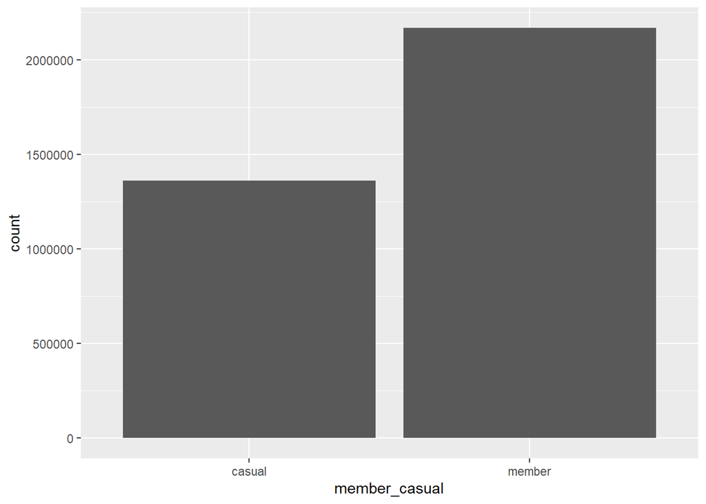

```r
ggplot(trips_cleaned) +
  geom_bar(mapping = aes(x = member_casual))
```

```r
trips_cleaned %>%
  group_by(member_casual) %>%
             summarise(Count = n())
```

```
## # A tibble: 2 x 2
##   member_casual   Count
##   <fct>           <int>
## 1 casual        1359398
## 2 member        2167602
```

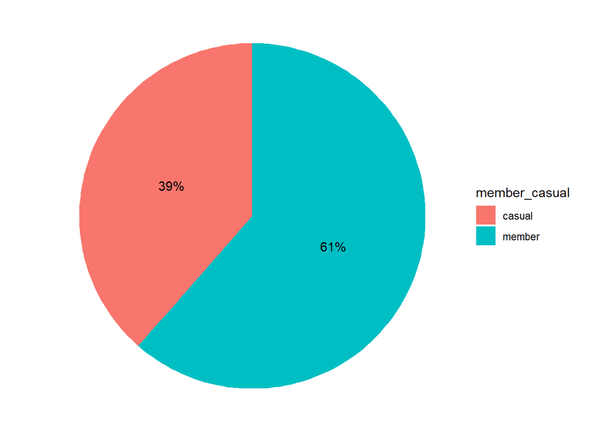

```r
grouped <- trips_cleaned %>%
  group_by(member_casual) %>%
  count() %>%
  ungroup() %>%
  mutate(per=`n`/sum(`n`)) %>%
  arrange(desc(member_casual))
grouped$label <- scales::percent(grouped$per)
ggplot(grouped)+
  geom_bar(aes(x="", y=per, fill=member_casual), stat="identity", width = 1)+
  coord_polar("y", start=0)+
  theme_void()+
  geom_text(aes(x=1, y = cumsum(per) - per/2, label=label))
```

### visualizing the number of rides by Average duration in Minutes throughout the week

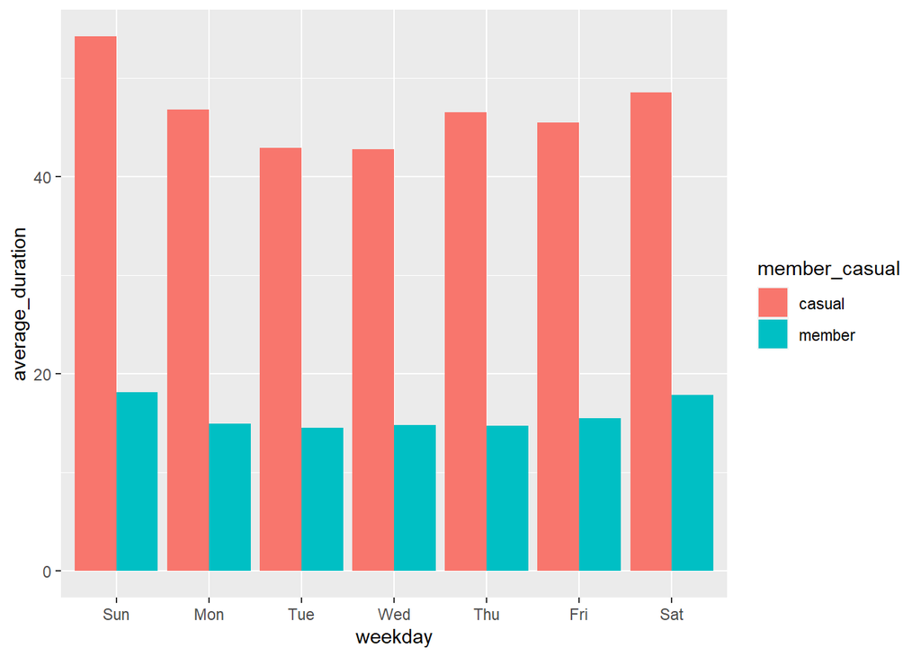

```r
trips_cleaned %>%
  mutate(weekday = wday(started_at, label = TRUE)) %>%
  group_by(member_casual, weekday) %>%
  summarise(numer_of_rides = n(), average_duration = mean(ride_length_minutes)) %>%
  arrange(member_casual, weekday) %>%
  ggplot(aes(x= weekday, y = average_duration, fill = member_casual)) +
  geom_col(position = 'dodge')
```

### visualizing the number of rides by rider type throughout the week

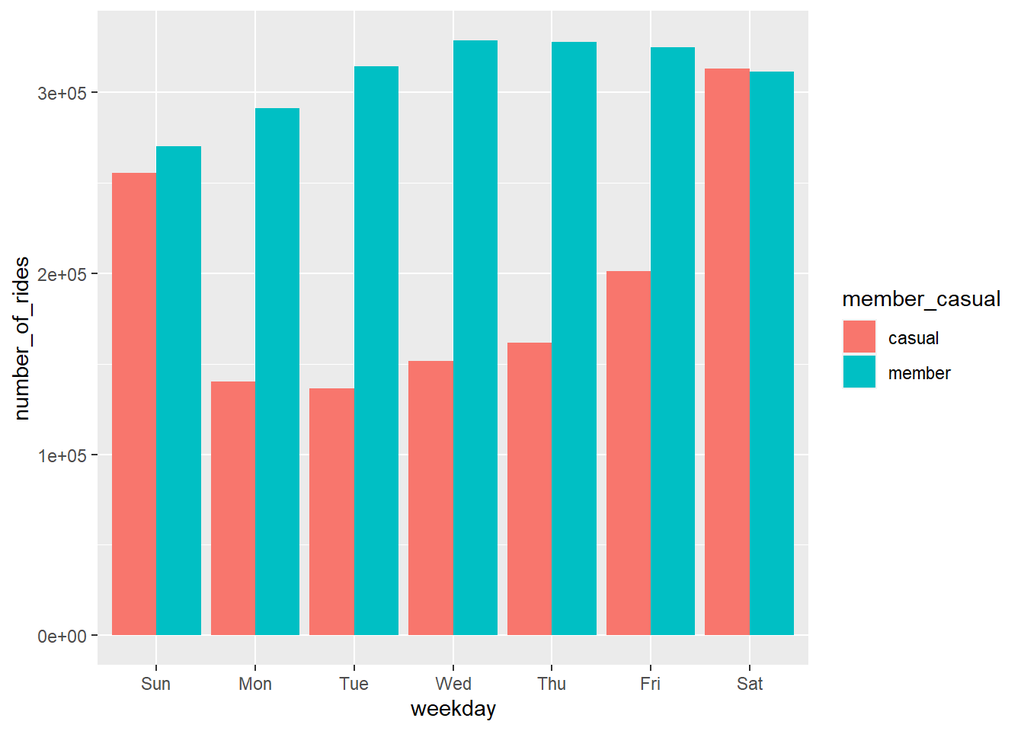

```r
trips_cleaned %>%
  mutate(weekday = wday(started_at, label = TRUE)) %>%
  group_by(member_casual, weekday) %>%
  summarise(number_of_rides = n()
            ,average_duration = mean(ride_length)) %>%
  arrange(member_casual, weekday)  %>%
  ggplot(aes(x = weekday, y = number_of_rides, fill = member_casual)) +
  geom_col(position = "dodge")
```

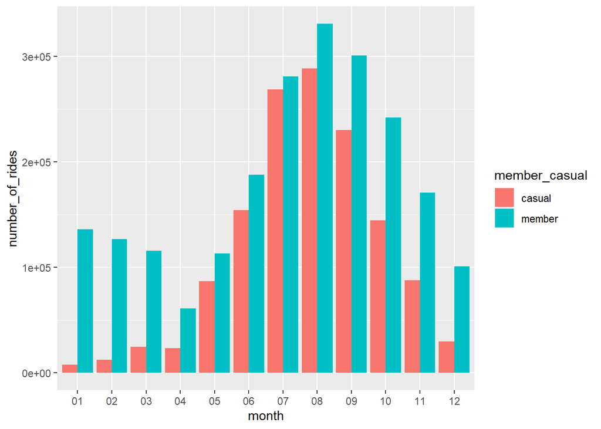

```r
trips_cleaned %>%
  group_by(member_casual, month) %>%
  summarise(number_of_rides = n()) %>%
  arrange(member_casual, month)  %>%
  ggplot(aes(x = month, y = number_of_rides, fill = member_casual)) +
  geom_col(position = "dodge")
```

```r
counts <- aggregate(trips_cleaned$ride_length_minutes ~ trips_cleaned$member_casual + trips_cleaned$day_of_week, FUN = mean)
```

```r
head(counts)
```

```
##   trips_cleaned$member_casual trips_cleaned$day_of_week
## 1                      casual                    Sunday
## 2                      member                    Sunday
## 3                      casual                    Monday
## 4                      member                    Monday
## 5                      casual                   Tuesday
## 6                      member                   Tuesday
##   trips_cleaned$ride_length_minutes
## 1                          54.25273
## 2                          18.15454
## 3                          46.82323
## 4                          14.95224
## 5                          42.92391
## 6                          14.52076
```

```r
write.csv(counts, "D:/Downloads/counts.csv")
```

```r
head(df)
```

```
##            ride_id rideable_type          started_at            ended_at
## 1 EACB19130B0CDA4A   docked_bike 2020-01-21 20:06:59 2020-01-21 20:14:30
## 2 8FED874C809DC021   docked_bike 2020-01-30 14:22:39 2020-01-30 14:26:22
## 3 789F3C21E472CA96   docked_bike 2020-01-09 19:29:26 2020-01-09 19:32:17
## 4 C9A388DAC6ABF313   docked_bike 2020-01-06 16:17:07 2020-01-06 16:25:56
## 5 943BC3CBECCFD662   docked_bike 2020-01-30 08:37:16 2020-01-30 08:42:48
## 6 6D9C8A6938165C11   docked_bike 2020-01-10 12:33:05 2020-01-10 12:37:54
##         start_station_name start_station_id               end_station_name
## 1 Western Ave & Leland Ave              239          Clark St & Leland Ave
## 2  Clark St & Montrose Ave              234 Southport Ave & Irving Park Rd
## 3   Broadway & Belmont Ave              296       Wilton Ave & Belmont Ave
## 4   Clark St & Randolph St               51       Fairbanks Ct & Grand Ave
## 5     Clinton St & Lake St               66          Wells St & Hubbard St
## 6    Wells St & Hubbard St              212    Desplaines St & Randolph St
##   end_station_id start_lat start_lng end_lat  end_lng member_casual
## 1          326.0   41.9665  -87.6884 41.9671 -87.6674        member
## 2          318.0   41.9616  -87.6660 41.9542 -87.6644        member
## 3          117.0   41.9401  -87.6455 41.9402 -87.6530        member
## 4           24.0   41.8846  -87.6319 41.8918 -87.6206        member
## 5          212.0   41.8856  -87.6418 41.8899 -87.6343        member
## 6           96.0   41.8899  -87.6343 41.8846 -87.6446        member
```

### Creating another version of the original df, to analyze stations and geography

```r
trips_v2 <- df
trips_v2$date <- as.Date(trips_v2$started_at) #The default format is yyyy-mm-dd
trips_v2$month <- format(as.Date(trips_v2$date), "%m")
trips_v2$day <- format(as.Date(trips_v2$date), "%d")
trips_v2$day_of_week <- format(as.Date(trips_v2$date), "%A")
```

```r
head(trips_v2)
```

```
##            ride_id rideable_type          started_at            ended_at
## 1 EACB19130B0CDA4A   docked_bike 2020-01-21 20:06:59 2020-01-21 20:14:30
## 2 8FED874C809DC021   docked_bike 2020-01-30 14:22:39 2020-01-30 14:26:22
## 3 789F3C21E472CA96   docked_bike 2020-01-09 19:29:26 2020-01-09 19:32:17
## 4 C9A388DAC6ABF313   docked_bike 2020-01-06 16:17:07 2020-01-06 16:25:56
## 5 943BC3CBECCFD662   docked_bike 2020-01-30 08:37:16 2020-01-30 08:42:48
## 6 6D9C8A6938165C11   docked_bike 2020-01-10 12:33:05 2020-01-10 12:37:54
##         start_station_name start_station_id               end_station_name
## 1 Western Ave & Leland Ave              239          Clark St & Leland Ave
## 2  Clark St & Montrose Ave              234 Southport Ave & Irving Park Rd
## 3   Broadway & Belmont Ave              296       Wilton Ave & Belmont Ave
## 4   Clark St & Randolph St               51       Fairbanks Ct & Grand Ave
## 5     Clinton St & Lake St               66          Wells St & Hubbard St
## 6    Wells St & Hubbard St              212    Desplaines St & Randolph St
##   end_station_id start_lat start_lng end_lat  end_lng member_casual       date
## 1          326.0   41.9665  -87.6884 41.9671 -87.6674        member 2020-01-21
## 2          318.0   41.9616  -87.6660 41.9542 -87.6644        member 2020-01-30
## 3          117.0   41.9401  -87.6455 41.9402 -87.6530        member 2020-01-09
## 4           24.0   41.8846  -87.6319 41.8918 -87.6206        member 2020-01-06
## 5          212.0   41.8856  -87.6418 41.8899 -87.6343        member 2020-01-30
## 6           96.0   41.8899  -87.6343 41.8846 -87.6446        member 2020-01-10
##   month day day_of_week
## 1    01  21     Tuesday
## 2    01  30    Thursday
## 3    01  09    Thursday
## 4    01  06      Monday
## 5    01  30    Thursday
## 6    01  10      Friday
```

### fixing some of the datatypes

```r
trips_v2$started_at <- as_datetime(trips_v2$started_at)
trips_v2$ended_at <- as_datetime(trips_v2$ended_at)
```

```r
trips_v2$rideable_type <- as.character(trips_v2$rideable_type)
trips_v2$start_station_name <- as.character(trips_v2$start_station_name)
trips_v2$start_station_id <- as.character(trips_v2$start_station_id)
trips_v2$end_station_name <- as.character(trips_v2$end_station_name)
trips_v2$end_station_id <- as.character(trips_v2$end_station_id)
trips_v2$member_casual <- as.character(trips_v2$member_casual)
```

## Adding trip duration in minutes

```r
trips_v2$ride_length <- difftime(trips_v2$ended_at, trips_v2$started_at)
trips_v2$ride_length <- as.numeric(trips_v2$ride_length)
```

```r
trips_v2$ride_length_minutes <- trips_v2$ride_length / 60
```

```r
trips_v2$day_of_week <- ordered(trips_v2$day_of_week, levels=c("Sunday", "Monday", "Tuesday", "Wednesday", "Thursday", "Friday", "Saturday"))
```

## gettng rid of -ve values in ride length and “maintainance in HQ QR”

```r
trips_v2 <- trips_v2[!(trips_v2$start_station_name == "HQ QR" | trips_v2$ride_length_minutes <= 0), ]
```

## test

```r
head(trips_v2)
```

```
##            ride_id rideable_type          started_at            ended_at
## 1 EACB19130B0CDA4A   docked_bike 2020-01-21 20:06:59 2020-01-21 20:14:30
## 2 8FED874C809DC021   docked_bike 2020-01-30 14:22:39 2020-01-30 14:26:22
## 3 789F3C21E472CA96   docked_bike 2020-01-09 19:29:26 2020-01-09 19:32:17
## 4 C9A388DAC6ABF313   docked_bike 2020-01-06 16:17:07 2020-01-06 16:25:56
## 5 943BC3CBECCFD662   docked_bike 2020-01-30 08:37:16 2020-01-30 08:42:48
## 6 6D9C8A6938165C11   docked_bike 2020-01-10 12:33:05 2020-01-10 12:37:54
##         start_station_name start_station_id               end_station_name
## 1 Western Ave & Leland Ave              239          Clark St & Leland Ave
## 2  Clark St & Montrose Ave              234 Southport Ave & Irving Park Rd
## 3   Broadway & Belmont Ave              296       Wilton Ave & Belmont Ave
## 4   Clark St & Randolph St               51       Fairbanks Ct & Grand Ave
## 5     Clinton St & Lake St               66          Wells St & Hubbard St
## 6    Wells St & Hubbard St              212    Desplaines St & Randolph St
##   end_station_id start_lat start_lng end_lat  end_lng member_casual       date
## 1          326.0   41.9665  -87.6884 41.9671 -87.6674        member 2020-01-21
## 2          318.0   41.9616  -87.6660 41.9542 -87.6644        member 2020-01-30
## 3          117.0   41.9401  -87.6455 41.9402 -87.6530        member 2020-01-09
## 4           24.0   41.8846  -87.6319 41.8918 -87.6206        member 2020-01-06
## 5          212.0   41.8856  -87.6418 41.8899 -87.6343        member 2020-01-30
## 6           96.0   41.8899  -87.6343 41.8846 -87.6446        member 2020-01-10
##   month day day_of_week ride_length ride_length_minutes
## 1    01  21     Tuesday         451            7.516667
## 2    01  30    Thursday         223            3.716667
## 3    01  09    Thursday         171            2.850000
## 4    01  06      Monday         529            8.816667
## 5    01  30    Thursday         332            5.533333
## 6    01  10      Friday         289            4.816667
```

## grouping data for visualization

```r
famous_start_station_name <- trips_v2 %>%
  group_by(start_station_name) %>%
  summarise(total_rides_station= n()) %>%
  arrange(desc(total_rides_station))
```

```r
head(famous_start_station_name, 10)
```

```
## # A tibble: 10 x 2
##    start_station_name           total_rides_station
##    <chr>                                      <int>
##  1 ""                                         94607
##  2 "Streeter Dr & Grand Ave"                  35238
##  3 "Clark St & Elm St"                        31807
##  4 "Theater on the Lake"                      29322
##  5 "Lake Shore Dr & Monroe St"                29105
##  6 "Lake Shore Dr & North Blvd"               26511
##  7 "Wells St & Concord Ln"                    25003
##  8 "Indiana Ave & Roosevelt Rd"               24582
##  9 "Millennium Park"                          24226
## 10 "Dearborn St & Erie St"                    24187
```

```r
famous_end_station_name <- trips_v2 %>%
  group_by(end_station_name) %>%
  summarise(total_rides_station= n()) %>%
  arrange(desc(total_rides_station))
```

```r
trips_v2$combined_station_name <- paste(trips_v2$start_station_name,"- ", trips_v2$end_station_name)
```

```r
combined_station_25 <- trips_v2 %>%
  group_by(combined_station_name, member_casual) %>%
  summarise(famous_stations= n()) %>%
  arrange(desc(famous_stations))
write.csv(head(combined_station_25, 25), "D:/Downloads/combined_station_25.csv")
```

```r
grouped_stations <- trips_v2 %>%
  group_by(combined_station_name, start_lat, start_lng, end_lat, end_lng) %>%
  summarise(Count =n()) %>%
  arrange(desc(Count))
head(grouped_stations)
```

```
## # A tibble: 6 x 6
## # Groups:   combined_station_name, start_lat, start_lng, end_lat [6]
##   combined_station_name                start_lat start_lng end_lat end_lng Count
##   <chr>                                    <dbl>     <dbl>   <dbl>   <dbl> <int>
## 1 Streeter Dr & Grand Ave -  Streeter~      41.9     -87.6    41.9   -87.6  5978
## 2 Lake Shore Dr & Monroe St -  Lake S~      41.9     -87.6    41.9   -87.6  5597
## 3 Indiana Ave & Roosevelt Rd -  India~      41.9     -87.6    41.9   -87.6  3799
## 4 Theater on the Lake -  Theater on t~      41.9     -87.6    41.9   -87.6  3407
## 5 Fort Dearborn Dr & 31st St -  Fort ~      41.8     -87.6    41.8   -87.6  3291
## 6 Shore Dr & 55th St -  Shore Dr & 55~      41.8     -87.6    41.8   -87.6  3065
```

```r
write.csv(head(grouped_stations,25), "D:/Downloads/grouped_stations.csv")
```

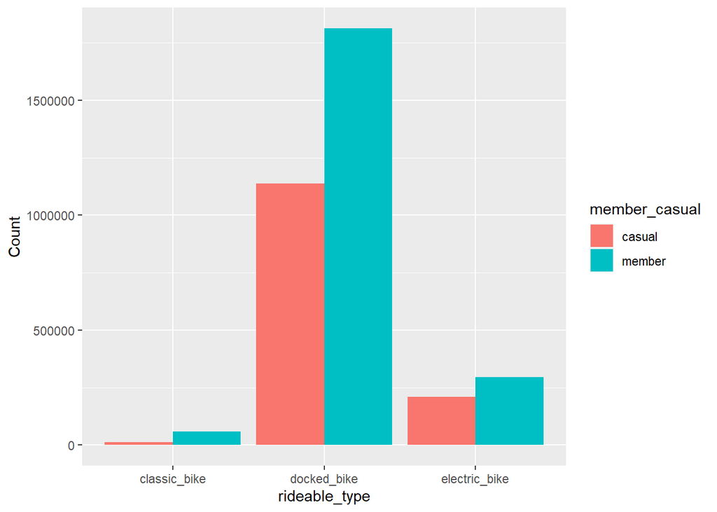

```r
trips_v2 %>%
  group_by(member_casual, rideable_type) %>%
  summarise(Count =n()) %>%
  arrange(desc(Count)) %>%
  ggplot(aes(x = rideable_type, y = Count, fill = member_casual)) +
  geom_col(position = "dodge")
```

### Docked Bike are the most famous and easier to find via smart phones mapping apps for members and casual, so **Docks** are special bike racks that lock the bike, and only release it by software control.

```r
ride_type <-trips_v2 %>%
  group_by(member_casual, rideable_type) %>%
  summarise(Count =n()) %>%
  arrange(desc(Count))
write.csv(ride_type, "D:/Downloads/ride_type.csv")
```